# Data Scientist Nanodegree

## Project: Write a Data Science Blog

### Business Understanding

In this project, the objective is to pick a dataset of your own choice and answer at least 3 questions related to business or real-world applications of how the data could be used.

Questions To Be Answered

Q1. What the dominated gender in data science and what is the highest age ratio?

Q2. What the most compensation the data scientists can get?

Q3: What media sources data scienticts get the information from?

### Data Understanding

The dataset that I have prepared for this project, it is Kaggle’s third annual survey. it includes 19,717 Kaggle members' respondents in the survey. To answer the 3 questions in interest, I'll focuse on the members that are currently employed as data scientists.

```python
# Import libraries:
import pandas as pd
from sklearn.model_selection import train_test_split
import matplotlib.pyplot as plt
import seaborn as sns
```

```python
# Load the 2019 Kaggle ML & DS Survey dataset
df = pd.read_csv('multiple_choice_responses.csv')
#df1 = pd.read_csv('other_text_responses.csv')
```

```python
df.head()
```

|  | Time from Start to Finish (seconds) | Q1 | Q2 | Q2_OTHER_TEXT | Q3 | Q4 | Q5 | Q5_OTHER_TEXT | Q6 | Q7 | ... | Q34_Part_4 | Q34_Part_5 | Q34_Part_6 | Q34_Part_7 | Q34_Part_8 | Q34_Part_9 | Q34_Part_10 | Q34_Part_11 | Q34_Part_12 | Q34_OTHER_TEXT |
| --- | --- | --- | --- | --- | --- | --- | --- | --- | --- | --- | --- | --- | --- | --- | --- | --- | --- | --- | --- | --- | --- |
| 0 | Duration (in seconds) | What is your age (# years)? | What is your gender? - Selected Choice | What is your gender? - Prefer to self-describe... | In which country do you currently reside? | What is the highest level of formal education ... | Select the title most similar to your current ... | Select the title most similar to your current ... | What is the size of the company where you are ... | Approximately how many individuals are respons... | ... | Which of the following relational database pro... | Which of the following relational database pro... | Which of the following relational database pro... | Which of the following relational database pro... | Which of the following relational database pro... | Which of the following relational database pro... | Which of the following relational database pro... | Which of the following relational database pro... | Which of the following relational database pro... | Which of the following relational database pro... |
| 1 | 510 | 22-24 | Male | -1 | France | Master’s degree | Software Engineer | -1 | 1000-9,999 employees | 0 | ... | NaN | NaN | NaN | NaN | NaN | NaN | NaN | NaN | NaN | -1 |
| 2 | 423 | 40-44 | Male | -1 | India | Professional degree | Software Engineer | -1 | > 10,000 employees | 20+ | ... | NaN | NaN | NaN | NaN | NaN | NaN | NaN | NaN | NaN | -1 |
| 3 | 83 | 55-59 | Female | -1 | Germany | Professional degree | NaN | -1 | NaN | NaN | ... | NaN | NaN | NaN | NaN | NaN | NaN | NaN | NaN | NaN | -1 |
| 4 | 391 | 40-44 | Male | -1 | Australia | Master’s degree | Other | 0 | > 10,000 employees | 20+ | ... | NaN | NaN | NaN | NaN | NaN | Azure SQL Database | NaN | NaN | NaN | -1 |

5 rows × 246 columns

```python
# Get the Basic info of the dataset
df.describe()
```

|  | Time from Start to Finish (seconds) | Q1 | Q2 | Q2_OTHER_TEXT | Q3 | Q4 | Q5 | Q5_OTHER_TEXT | Q6 | Q7 | ... | Q34_Part_4 | Q34_Part_5 | Q34_Part_6 | Q34_Part_7 | Q34_Part_8 | Q34_Part_9 | Q34_Part_10 | Q34_Part_11 | Q34_Part_12 | Q34_OTHER_TEXT |
| --- | --- | --- | --- | --- | --- | --- | --- | --- | --- | --- | --- | --- | --- | --- | --- | --- | --- | --- | --- | --- | --- |
| count | 19718 | 19718 | 19718 | 19718 | 19718 | 19324 | 19108 | 19718 | 14003 | 13624 | ... | 1853 | 1193 | 548 | 589 | 416 | 480 | 527 | 1246 | 288 | 19718 |
| unique | 5305 | 12 | 5 | 49 | 60 | 8 | 13 | 961 | 6 | 8 | ... | 2 | 2 | 2 | 2 | 2 | 2 | 2 | 2 | 2 | 168 |
| top | 450 | 25-29 | Male | -1 | India | Master’s degree | Data Scientist | -1 | 0-49 employees | 20+ | ... | Microsoft SQL Server | Oracle Database | Microsoft Access | AWS Relational Database Service | AWS DynamoDB | Azure SQL Database | Google Cloud SQL | None | Other | -1 |
| freq | 36 | 4458 | 16138 | 15583 | 4786 | 8549 | 4085 | 14605 | 4025 | 3178 | ... | 1852 | 1192 | 547 | 588 | 415 | 479 | 526 | 1245 | 287 | 15439 |

4 rows × 246 columns

```python
df.info()
```

```
<class 'pandas.core.frame.DataFrame'>
RangeIndex: 19718 entries, 0 to 19717
Columns: 246 entries, Time from Start to Finish (seconds) to Q34_OTHER_TEXT
dtypes: object(246)
memory usage: 18.5+ MB
```

```python
# To check the column names in the dataset
list(df.columns.values)
```

```
['Time from Start to Finish (seconds)',
 'Q1',
 'Q2',
 'Q2_OTHER_TEXT',
 'Q3',
 'Q4',
 'Q5',
 'Q5_OTHER_TEXT',
 'Q6',
 'Q7',
 'Q8',
 'Q9_Part_1',
 'Q9_Part_2',
 'Q9_Part_3',
 'Q9_Part_4',
 'Q9_Part_5',
 'Q9_Part_6',
 'Q9_Part_7',
 'Q9_Part_8',
 'Q9_OTHER_TEXT',
 'Q10',
 'Q11',
 'Q12_Part_1',
 'Q12_Part_2',
 'Q12_Part_3',
 'Q12_Part_4',
 'Q12_Part_5',
 'Q12_Part_6',
 'Q12_Part_7',
 'Q12_Part_8',
 'Q12_Part_9',
 'Q12_Part_10',
 'Q12_Part_11',
 'Q12_Part_12',
 'Q12_OTHER_TEXT',
 'Q13_Part_1',
 'Q13_Part_2',
 'Q13_Part_3',
 'Q13_Part_4',
 'Q13_Part_5',
```

[output cut: 191 more lines]

```
 'Q33_Part_12',
 'Q33_OTHER_TEXT',
 'Q34_Part_1',
 'Q34_Part_2',
 'Q34_Part_3',
 'Q34_Part_4',
 'Q34_Part_5',
 'Q34_Part_6',
 'Q34_Part_7',
 'Q34_Part_8',
 'Q34_Part_9',
 'Q34_Part_10',
 'Q34_Part_11',
 'Q34_Part_12',
 'Q34_OTHER_TEXT']
```

### Data Preparation

Some data preparation steps need to be done before using the dataset for exploration, including:

1- Reterive only rows that are related to Data scientists member in the survey.

2- Change the name of the coulmns to make them readable.

3- Dealing with missing values.

```python
column_mapping = {'Q1':'Age',
'Q2':'Gender',
'Q3':'Country',
'Q4':'Degree',
'Q5':'Job Title',
'Q6':'Company Size',
'Q7':'Team Size',
'Q8':'ML Status in Company',
'Q10':'Compensation Status',
'Q11':'Money Spent'
}

df = df.rename(columns= column_mapping)
df= df.drop([0], errors='ignore')
df.head()
```

|  | Time from Start to Finish (seconds) | Age | Gender | Q2_OTHER_TEXT | Country | Degree | Job Title | Q5_OTHER_TEXT | Company Size | Team Size | ... | Q34_Part_4 | Q34_Part_5 | Q34_Part_6 | Q34_Part_7 | Q34_Part_8 | Q34_Part_9 | Q34_Part_10 | Q34_Part_11 | Q34_Part_12 | Q34_OTHER_TEXT |
| --- | --- | --- | --- | --- | --- | --- | --- | --- | --- | --- | --- | --- | --- | --- | --- | --- | --- | --- | --- | --- | --- |
| 1 | 510 | 22-24 | Male | -1 | France | Master’s degree | Software Engineer | -1 | 1000-9,999 employees | 0 | ... | NaN | NaN | NaN | NaN | NaN | NaN | NaN | NaN | NaN | -1 |
| 2 | 423 | 40-44 | Male | -1 | India | Professional degree | Software Engineer | -1 | > 10,000 employees | 20+ | ... | NaN | NaN | NaN | NaN | NaN | NaN | NaN | NaN | NaN | -1 |
| 3 | 83 | 55-59 | Female | -1 | Germany | Professional degree | NaN | -1 | NaN | NaN | ... | NaN | NaN | NaN | NaN | NaN | NaN | NaN | NaN | NaN | -1 |
| 4 | 391 | 40-44 | Male | -1 | Australia | Master’s degree | Other | 0 | > 10,000 employees | 20+ | ... | NaN | NaN | NaN | NaN | NaN | Azure SQL Database | NaN | NaN | NaN | -1 |
| 5 | 392 | 22-24 | Male | -1 | India | Bachelor’s degree | Other | 1 | 0-49 employees | 0 | ... | NaN | NaN | NaN | NaN | NaN | NaN | NaN | NaN | NaN | -1 |

5 rows × 246 columns

```python
# retreive only rows with current role as Data Scientists and keep it in df_Data_Scientist variable

Job_Title = 'Data Scientist'
df_Data_Scientist = df[(df['Job Title'] == Job_Title)]
df_row = df[~(df['Job Title'] == Job_Title)]
```

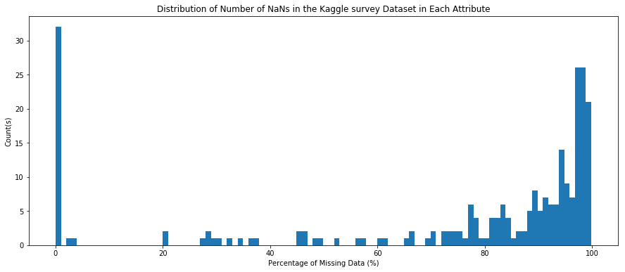

```python
# Count number of NaNs in each attribute
null_number = df.isnull().sum()
plt.figure(figsize=(15, 6))
plt.title('Distribution of Number of NaNs in the Kaggle survey Dataset in Each Attribute')
plt.hist(null_number / df.shape[0] * 100, bins=100)
plt.xlabel('Percentage of Missing Data (%)')
plt.ylabel('Count(s)')
plt.show()
```

```python
# Peek at attributes with under and over 1% of missing values
data_under_1 = (null_number / len(df) * 100) <= 1
data_over_1 = (null_number / len(df) * 100) > 1
attri_over_1 = null_number.loc[(null_number / df.shape[0] * 100) > 1]
print("Attributes with equal to or under 1% of missing data: {}".format(data_under_1.sum()))
print("Attributes with over 1% of missing data: {}".format(data_over_1.sum()))
print("Attributes with missing data that exceeds 1%: \n{}".format(attri_over_1 / df.shape[0] * 100))
```

```
Attributes with equal to or under 1% of missing data: 32
Attributes with over 1% of missing data: 214
Attributes with missing data that exceeds 1%:
Degree                   1.998276
Job Title                3.093777
Company Size            28.985140
Team Size               30.907339
ML Status in Company    32.915758
Q9_Part_1               69.107876
Q9_Part_2               81.914084
Q9_Part_3               74.737536
Q9_Part_4               83.019729
Q9_Part_5               81.209109
Q9_Part_6               88.035705
Q9_Part_7               97.306893
Q9_Part_8               98.737130
Compensation Status     36.618147
Money Spent             37.870873
Q12_Part_1              81.031597
Q12_Part_2              90.850535
Q12_Part_3              82.659634
Q12_Part_4              45.473449
Q12_Part_5              80.955521
Q12_Part_6              61.769032
Q12_Part_7              89.476087
Q12_Part_8              49.754019
Q12_Part_9              77.319065
Q12_Part_10             87.766902
Q12_Part_11             97.083735
Q12_Part_12             93.995030
Q13_Part_1              85.023077
Q13_Part_2              55.951717
Q13_Part_3              84.023939
                          ...
Q32_Part_7              97.971294
Q32_Part_8              98.655982
Q32_Part_9              98.402394
Q32_Part_10             97.114165
Q32_Part_11             78.125475
Q32_Part_12             98.858853
```

[output cut: 10 more lines]

```
Q33_Part_11             73.753614
Q33_Part_12             99.330527
Q34_Part_1              84.165948
Q34_Part_2              89.044987
Q34_Part_3              92.255414
Q34_Part_4              90.607090
Q34_Part_5              93.954456
Q34_Part_6              97.225744
Q34_Part_7              97.017802
Q34_Part_8              97.895217
Q34_Part_9              97.570624
Q34_Part_10             97.332251
Q34_Part_11             93.685652
Q34_Part_12             98.544403
Length: 214, dtype: float64
```

To answer my questions, I'll deall with missing values in job title, compensation status. for Age and gender coulmns, there's no missing values. Also Q12*part* from 1 to 12, I'll count only the values in each row ignoring the missing values.

```python
df['Compensation Status'].dropna(axis=0, how='any', inplace=True)
df['Job Title'].dropna(axis=0, how='any', inplace=True)
```

```python
#df1=df.loc[df['Job Title'] == Job_Title]
```

```python
# function that plotting bar plot
def bar_plot(x , y,  data, hue = None, axis = 'vertical', title= None, show_percent = True, xlabel = None, ylabel= None, legend= None):
  if hue is None:
    ax = sns.barplot(y = y , x = x, data = data)
  if hue is not None:
    ax = sns.barplot(y = y , x = x, hue=hue, data = data)
  plt.title(title)
  # if legend is not None:
  #   plt.legend(legend)
  if show_percent:
    if axis == 'vertical':
      for p in ax.patches:
        percentage = '{:.2f}%'.format(p.get_y() + p.get_height())
        x = p.get_x() + p.get_width()/2
        y = p.get_y() + p.get_height() + 0.4
        #ax.annotate(percentage, (x, y))
        ax.text(x, y, percentage, ha="center")


    elif axis == 'horizontal':
      for p in ax.patches:
        percentage = '{:.2f}%'.format(p.get_x() + p.get_width())
        x = p.get_x() + p.get_width() + 0.2
        y = p.get_y() + p.get_height()/2
        ax.annotate(percentage, (x, y))
        #ax.text(x, y, percentage, ha="right")
  if xlabel is not None:
    plt.xlabel(xlabel);
  if ylabel is not None:
    plt.ylabel(ylabel);
  plt.show()
```

```python
# function to count the values in Dataframe
def value_counts(df, column, normalize= True, rename= 'Percentage', return_percent= True):
    if rename is not None and return_percent:
        mod_df= df[column].value_counts(normalize=normalize).rename(rename).mul(100).reset_index()
        mod_df= mod_df.rename(columns ={'index':column})
        return mod_df
```

### Answer Questions base on dataset

**Q1: What ages and gender are most data scientists fall into it?**

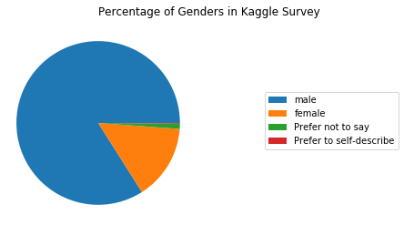

```python
title = plt.title('Percentage of Genders in Kaggle Survey')
title.set_ha("left")
plt.gca().axis("equal")
pie = plt.pie(df_Data_Scientist['Gender'].value_counts(), startangle=0)
labels=["male", "female", "Prefer not to say", "Prefer to self-describe"]
plt.legend(pie[0],labels, bbox_to_anchor=(1,0.5), loc="center right", fontsize=10,
           bbox_transform=plt.gcf().transFigure)
plt.subplots_adjust(left=0.0, bottom=0.1, right=0.45)
```

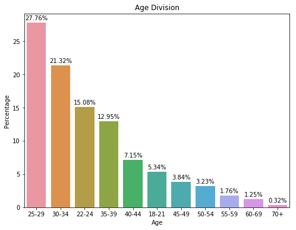

```python
gender = df_Data_Scientist['Age'].value_counts(normalize=True).rename('Percentage').mul(100).reset_index()
fig, ax = plt.subplots(figsize=(8,6))
bar_plot(x='index' ,y= 'Percentage', data = gender, axis = 'vertical', xlabel='Age', ylabel='Percentage', title='Age Division')
```

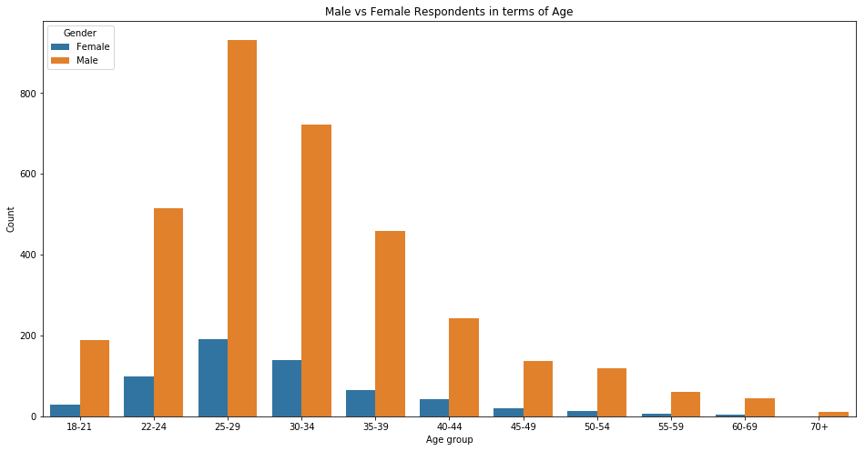

```python
# male to female sex ratio age wise

filter_age_gender = df_Data_Scientist.groupby(['Gender','Age']).count().reset_index()[['Gender','Age','Country']]
filter_age_gender =  filter_age_gender.loc[filter_age_gender['Gender'].isin(['Male', 'Female'])]
filter_age_gender

fig, ax = plt.subplots(figsize=(16,8))
bar_plot(x='Age', y ='Country', hue='Gender', data= filter_age_gender, title = 'Male vs Female Respondents in terms of Age', xlabel='Age group', ylabel='Count', show_percent=False, legend= 'Gender')
#sns.barplot(x='Age', y ='Country', hue='Gender', data= filter_age_gender,  ax=ax)
```

- The plots are clearly shown that the dominated gender in data science is male gender. more than 75% people are male. But still the female numbers are quite encouraging.
- about 40% data scientists are in the age group 22-29.
- Interestingly, most of the data scientists are young in the age group 25-29 and most of the female respondents also come from this age group.
- more 10% of the respondents are from a higher age group who may be at senior architect, technologist level.
- Surpisingly there are records for people in the category > 60. So this shows there is no age for passion. People of age 60 years are also using Data Science to run their businesses or just for the learning purpose. Lets see.

**Q2: what the most compensation the data scientists can get?**

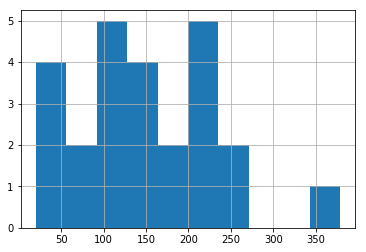

```python
df_salary=df_Data_Scientist['Compensation Status'].value_counts()
df_salary.hist()
```

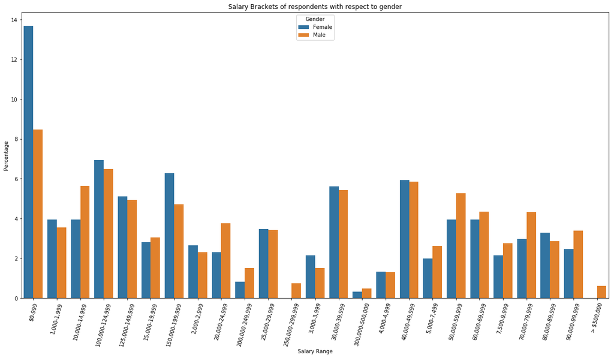

```python
filter_gender_salary = df_Data_Scientist.groupby(['Compensation Status', 'Gender']).count().reset_index()[['Compensation Status','Gender','Country']]
filter_gender_salary = filter_gender_salary[filter_gender_salary['Gender'].isin(['Male','Female'])]
total_female = df_Data_Scientist.groupby('Gender').count().reset_index()[['Gender', 'Country']].iloc[0,1]
total_male = df_Data_Scientist.groupby('Gender').count().reset_index()[['Gender', 'Country']].iloc[1,1]

def normalized_row(row):
  if row['Gender'] == 'Female':
    row['Degree_P'] = (row['Country'] / total_female) * 100
  if row['Gender'] == 'Male':
    row['Degree_P'] = (row['Country'] / total_male) * 100
  return row

filter_gender_salary = filter_gender_salary.apply(normalized_row, axis=1)
fig, ax = plt.subplots(figsize=(20,10))
plt.xticks(rotation=75)
bar_plot('Compensation Status', 'Degree_P', hue='Gender', data=filter_gender_salary, title='Salary Brackets of respondents with respect to gender', xlabel='Salary Range', ylabel='Percentage', show_percent= False);
#filter_gender_salary
```

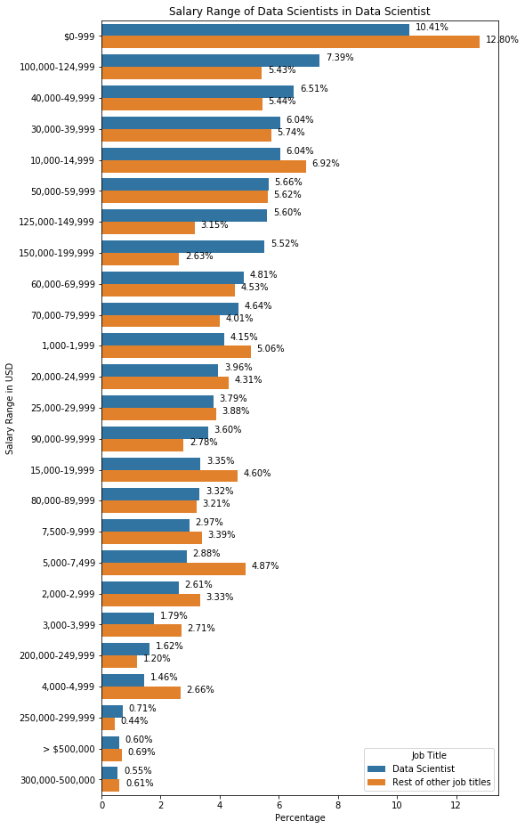

```python
compensation = value_counts(df_Data_Scientist, 'Compensation Status')
compensation_row = value_counts(df_row, 'Compensation Status')
compensation_concat = combine_row_Data_Scientist(compensation, compensation_row)
compensation_concat

fig, ax= plt.subplots(figsize=(8,16))
bar_plot(y='Compensation Status' ,x= 'Percentage',hue='Job Title',  data = compensation_concat, axis = 'horizontal', xlabel='Percentage', ylabel='Salary Range in USD', title='Salary Range of Data Scientists in '+Job_Title)
```

- The highest percentage of salary goes to 0-999 USD
- I think DS people are working as a hoppy in part time jobs or working for small campanies that don't pay much. This explains the low Salary they get.
- The lowest percentage they get is 300,000-500,00 USD which I beleive it makes sense as this role requires much experince from DS and a few people have the experince to work in big companies that lead the data science field.

**Q3: What Media Sources data scienticts gets the information from?**

```python
def multiple_answers(limit, df, col, mod_name):
    dict_local = {}

    for i in range(1, limit+1):
        col_name = col + str(i)
        new_col_name = df[col_name].value_counts().reset_index().iloc[0,0]
        dict_local[new_col_name]  = df[col_name].value_counts().reset_index().iloc[0,1]

    new_df = pd.DataFrame(dict_local, index=[0])
    new_df = new_df.melt()
    new_df = new_df.sort_values(by='value', ascending=False)
    new_df = new_df.rename(columns= {'variable':mod_name, 'value':'Count'})
    return new_df
```

```python
def combine_row_Data_Scientist(df_Data_Scientist, df_row):
    df_Data_Scientist['Job Title'] = Job_Title
    df_row['Job Title'] = 'Rest of other job titles'
    concat = pd.concat([df_Data_Scientist,  df_row], axis = 0).reset_index(drop=True)
    column = list(df_Data_Scientist.columns)[0]
    length_1 = list(df_Data_Scientist[column].unique())
    length_2 = list(df_row[column].unique())
    dict_more=[]
    if(len(length_1) == len(length_2)):
        return concat
    elif(len(length_1) > len(length_2)):
        not_present = []
        for col in length_1:
            if col not in length_2:
                not_present.append(col)
        for col in not_present:
            dict_more.append([col, 0, 'Rest of other job titles'])

    elif(len(length_1) < len(length_2)):
        not_present = []
        for col in length_2:
            if col not in length_1:
                not_present.append(col)
        for col in not_present:
            dict_more.append([col, 0, Job_Title])

    new_df = pd.DataFrame(dict_more, columns=[column, 'Percentage', 'Job Title'])
    #print(new_df)
    concat = pd.concat([concat,  new_df], axis = 0).reset_index(drop=True)
    return concat
```

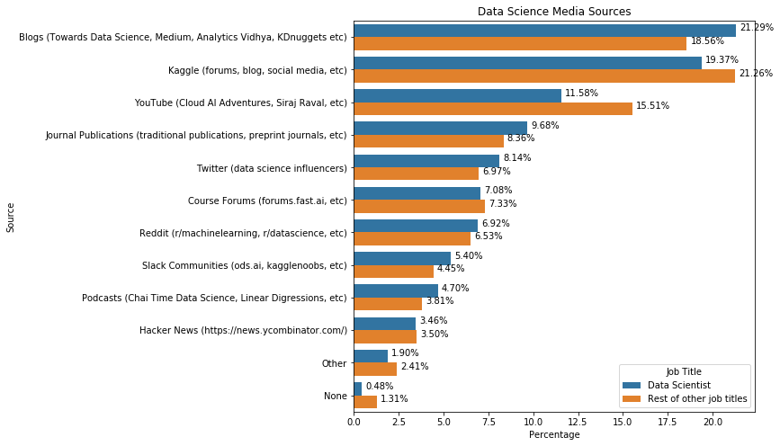

```python
## Media Sources
limit = 12

media = multiple_answers(limit, df_Data_Scientist, 'Q12_Part_', 'Media Sources')
media['Percentage']= (media.Count /  media.Count.sum()) * 100
media_row = multiple_answers(limit, df_row, 'Q12_Part_', 'Media Sources')
media_row['Percentage']= (media_row.Count /  media_row.Count.sum()) * 100
media_concat = combine_row_Data_Scientist(media, media_row)

#media_sources
fig, ax= plt.subplots(figsize=(8,8))
bar_plot(y='Media Sources' ,x= 'Percentage', hue='Job Title', data = media_concat, axis = 'horizontal', ylabel='Source', xlabel='Percentage', title='Data Science Media Sources')
#media_concat
```